# Part II - Factors affecting Trip Duration of Ford GoBike System

## by Ajibade Misturah

## Investigation Overview

> The goal of this prsentation is to show thw factors that influence the trip dutaion of a bike sharing app: Ford GoBike.

## Dataset Overview

> The dataset used is of Ford GoBike system data. It is a bike trip data for individual rides made in a bike-sharing system covering the greater San Francisco Bay area in February 2019. The Dataset consists of information regarding 183412 bike trips, including its timing, location of the start and end of each trip, duration of trips, user tpes and gender of users. I converted the data types of start_time and end_time to datetime formart. I also change the ids to float data type. After that I removed missing rows. I was also able to derive the weekday as well as duration of trips in minute.

## Visualization 1

> Subcriber user types takes most trips compare to customer user type

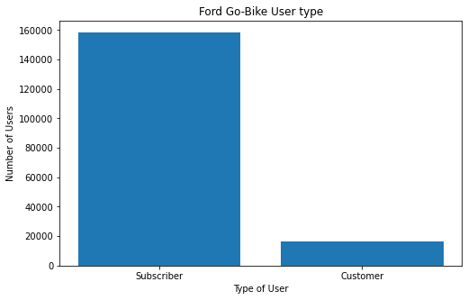

[figure not shown]

## Visualization 2

> However, customers have longer trips than subscribers

[figure not shown]

## Visualization 3

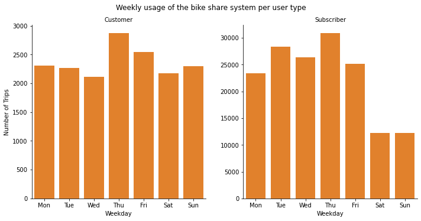

## Visualization 4

> In a clearer visualisation, we can see clearly the previous conclusions.

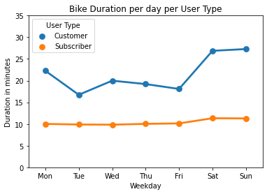